# Safe Babies Car Seat Price Optimization

Mark Bruner

March 21, 2021

### Loading libraries needed for project

```r
library(tidyverse)
library(glmnet)
library(corrplot)
library(ISLR)
```

### Loading Carseats dataset

```r
safe_babies <- Carseats %>%
  select("Sales", "Price", "ShelveLoc")

  # Creating profit column for future visualizations.
  # Equation for profit: (price - cost) * (quantity of sales)
safe_babies$profit <- (safe_babies$Price - 55) * safe_babies$Sales
```

# **Part 1: Exploratory Data Analysis**

## **Univariate Analysis**

### Measures of Central Tendancy and Dispersion

All columns have means and medians fairly close together, which means that they are more normally distributed. The 1st and 3rd quartiles are mostly symmetrical around the mean/median. The “ShelveLoc” column’s category “Medium” is where over 50% of the carseats are located.

```
##      Sales            Price        ShelveLoc       profit
##  Min.   : 0.000   Min.   : 24.0   Bad   : 96   Min.   :-323.3
##  1st Qu.: 5.390   1st Qu.:100.0   Good  : 85   1st Qu.: 287.1
##  Median : 7.490   Median :117.0   Medium:219   Median : 399.9
##  Mean   : 7.496   Mean   :115.8                Mean   : 426.1
##  3rd Qu.: 9.320   3rd Qu.:131.0                3rd Qu.: 549.1
##  Max.   :16.270   Max.   :191.0                Max.   :1057.8
```

### Histograms of Carseats in Good Shelf locations

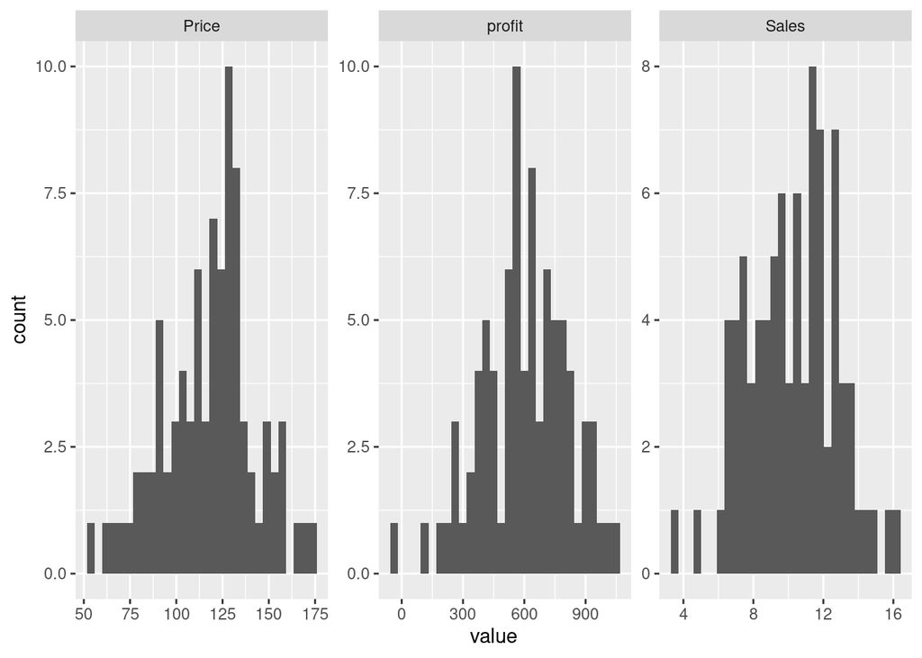

### Histograms of Carseats in Bad Shelf locations

From these plots, it confirms that the columns are more normally distributed. The price column seems to have an outlier that is more extreme but since the dataset if fairly small, 1 price that is outside the norm is worth looking into but it doesn’t seem too extreme.

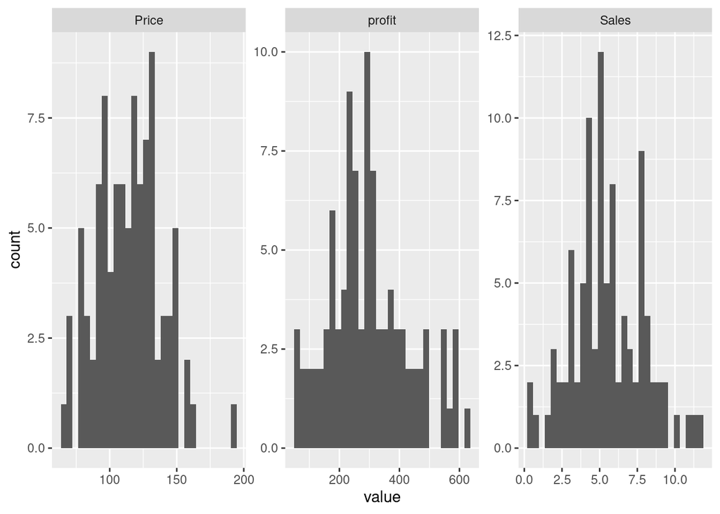

## **Bivariate Analysis**

### Relationship Between Sales & Price

Their is a negative relationship between sales and price, which is what you would expect. As price increases, sales decrease and visa versa. You would also expect carseats placed in a good shelf location would have, on average, higher sales. The lower the shelf location the lower the sales. You can see that the green dots (representing good shelf location), have mostly higher sales compared to the other locations.

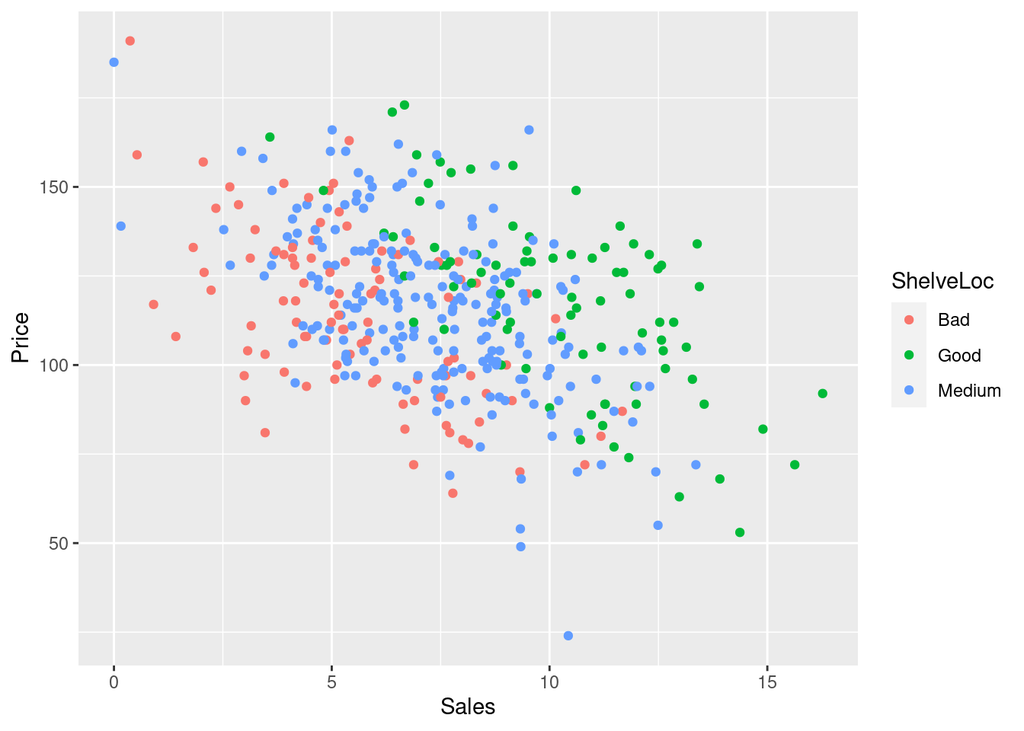

### Outliers and Data Spread by Shelf Location

### Boxplot Analysis

Most of the outliers were in the medium shelf location and the better the shelf location the better the sales, on average. The other interesting relationship was that the price spread for both medium and good shelf locations were almost identical.

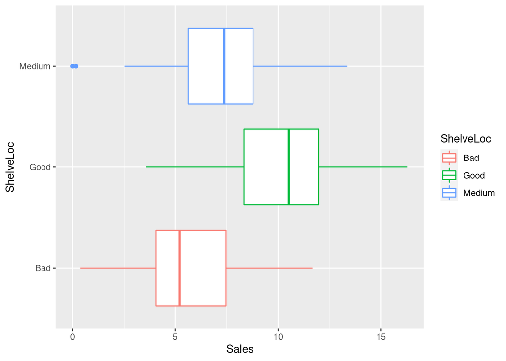

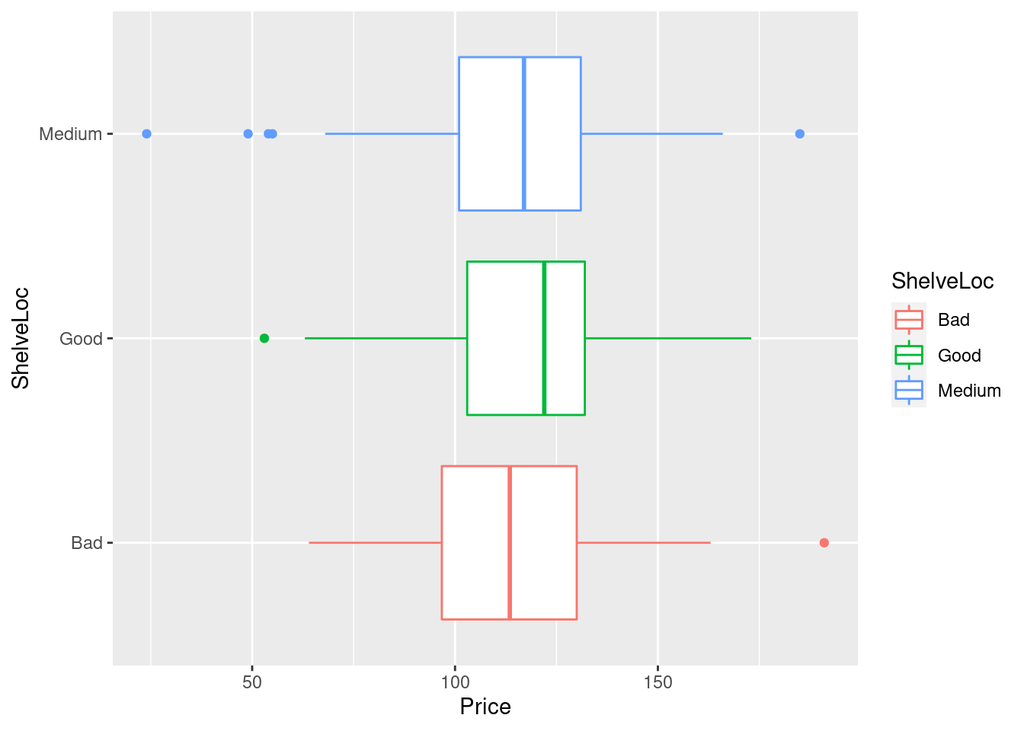

```
##     Sales Price ShelveLoc  profit
## 43  10.43    24    Medium -323.33
## 126  9.34    49    Medium  -56.04
## 368 14.37    53      Good  -28.74
## 314  9.33    54    Medium   -9.33
## 172 12.49    55    Medium    0.00
## 107  0.16   139    Medium   13.44
## 175  0.00   185    Medium    0.00
## 166  0.37   191       Bad   50.32
```

**I don’t see any mistakes. The negative profit is associated with those with prices below the $55 cost which is to be expected. The others with high prices have low sales which again makes sense.**

### **Multivariate Analysis**

The price, good and bad shelf locations are all fairly uncorrelated. The good and bad shelf locations have a slight negative correlation of .29 but shouldn’t be too much of a problem. Medium is highly negatively correlated with good and bad.

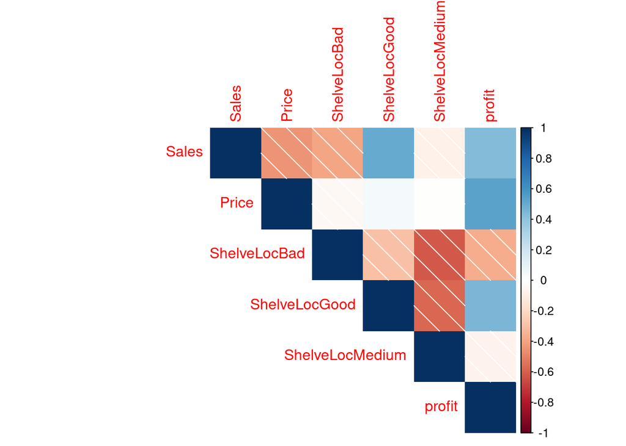

```r
# One hot encoding the shelf location to keep them in the glm.
safe_babies_mx <- model.matrix( ~ .-1, safe_babies[,1:4])

# Separating the sales variable from the other variables. Will check to see if the predictors are independent of one another.
x = safe_babies_mx[, 2:5]
y = safe_babies_mx[, 1]

safebabies_cor <- cor(safe_babies_mx)

corrplot(safebabies_cor, method = "shade", type = "upper")
```

# **Part 2: Model Building**

### Optimal GLM model for Sales & Price Based on Location

```r
# Using 20 fold cross-validation to find the optimal glm model for our dataset.
for (a in seq(0,1,by=0.1)) {
cv.fit <- cv.glmnet(x, y, alpha = a, nfolds = 20)
print(paste0("alpha is ", a, " and best MSE is " , min(cv.fit$cvm)))
}
```

```
## [1] "alpha is 0 and best MSE is 3.72694776969948"
## [1] "alpha is 0.1 and best MSE is 3.71248850002508"
## [1] "alpha is 0.2 and best MSE is 3.70468912930444"
## [1] "alpha is 0.3 and best MSE is 3.70946549524002"
## [1] "alpha is 0.4 and best MSE is 3.68447529978737"
## [1] "alpha is 0.5 and best MSE is 3.70776062946084"
## [1] "alpha is 0.6 and best MSE is 3.71278751499905"
## [1] "alpha is 0.7 and best MSE is 3.7256660751347"
## [1] "alpha is 0.8 and best MSE is 3.71948639092741"
## [1] "alpha is 0.9 and best MSE is 3.73138351913329"
## [1] "alpha is 1 and best MSE is 3.72646834892945"
```

```r
# The Best Fit Model for This Dataset
best_fit <- coef(cv.fit, s = "lambda.min")
best_fit
```

```
## 5 x 1 sparse Matrix of class "dgCMatrix"
##                           1
## (Intercept)     13.81940138
## Price           -0.05631621
## ShelveLocBad    -1.84605181
## ShelveLocGood    3.01699343
## ShelveLocMedium  .
```

# **Part 3: Optimal Price for $55 Cost**

```r
# Created a function to find the optimal value based on shelf location.
# cost is the cost of carseat production, good and bad represent shelf location and they are binary.
optimal <- function(cost, good, bad) {
  # Derivative of the first term in the quadratic profit equation
  x1 <- 2*best_fit[2]

  #Derivative of the second term in the profit equation
   x2 <- -1*best_fit[1] +
     -1*best_fit[3] * bad +
     -1*best_fit[4] * good +
     (best_fit[2]*cost)

  #Solving the derivative for max price unknown
   optimal_price <- x2/x1

   optimal_sales <- best_fit[1] + best_fit[3] * bad + best_fit[4]*good + best_fit[2]*optimal_price

   optimal_profit <- (optimal_price - cost) * optimal_sales
   return(as.data.frame(cbind("price" = round(optimal_price, 2),
                              "sales" = round(optimal_sales, 2),
                              "profit" = round(optimal_profit, 2))))
}
```

### Optimal Price, Sales, and Profit for Good Shelf Location

```r
optimal(55, 1, 0)
```

```
##    price sales profit
## 1 176.98  6.87 837.95
```

#### Optimal price for a $55 cost is $176.98 or $177. Optimal sales is 6.87 thousand carseats which will provide $837.95 thousand dollar profit.

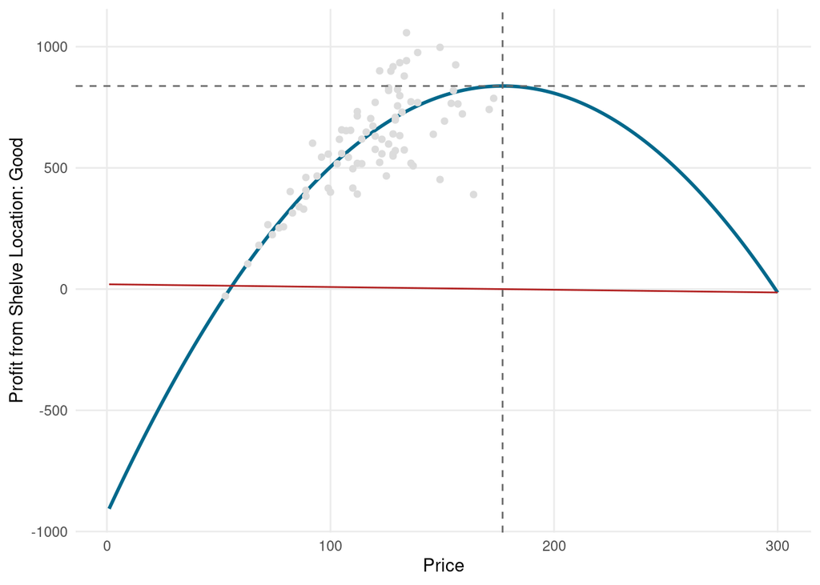

**The plot above shows the fit of the profit quadratic equation to the good shelf data and shows that the derivative intercepts the x-axis at the optimal price of $177.**

### Optimal Price, Sales, and Profit for Bad Shelf Location

```r
optimal(55, 0, 1)
```

```
##   price sales profit
## 1 133.8  4.44 349.73
```

#### Optimal price for bad shelf location at a 55 cost is $133.8 or about $134. Optimal sales is 4.44 thousand carseats which will provide $349.73 thousand dollar profit.

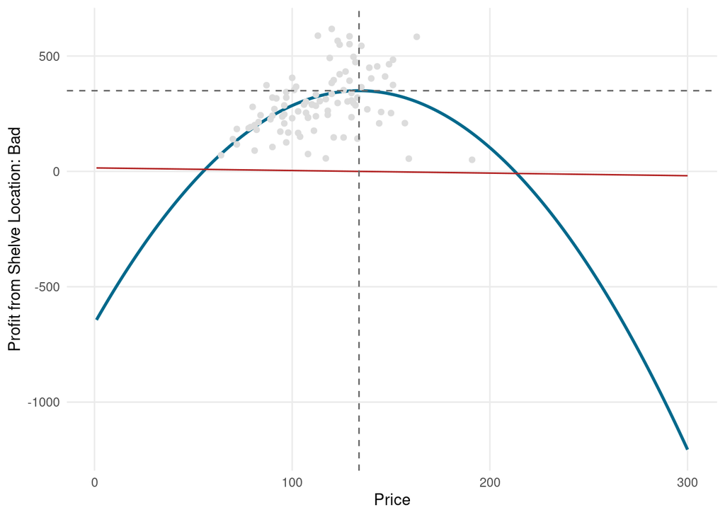

```r
# Creating
costs <- as.data.frame(seq(40, 85, by = 5))
costs <- costs %>%
          rename('costs'=`seq(40, 85, by = 5)`)
```

```r
for(i in costs) {
  # i-th element of `costs` used to find good shelf optimal sales, price, and profit
  good_results <- as.data.frame(optimal(i, 1, 0))
  good_results <- (cbind(costs, good_results))
}
```

```r
for(i in costs) {
  # i-th element of `costs` used to find bad shelf optimal sales, price, and profit
  bad_results <- as.data.frame(optimal(i, 0, 1))
  bad_results <- (cbind(costs, bad_results))
}
```

```r
good_results %>%
  mutate(profit_margin_percent = round((price-costs)/price *100))
```

[output not shown]

```r
bad_results %>%
  mutate(profit_margin_percent = round((price-costs)/price *100))
```

[output not shown]

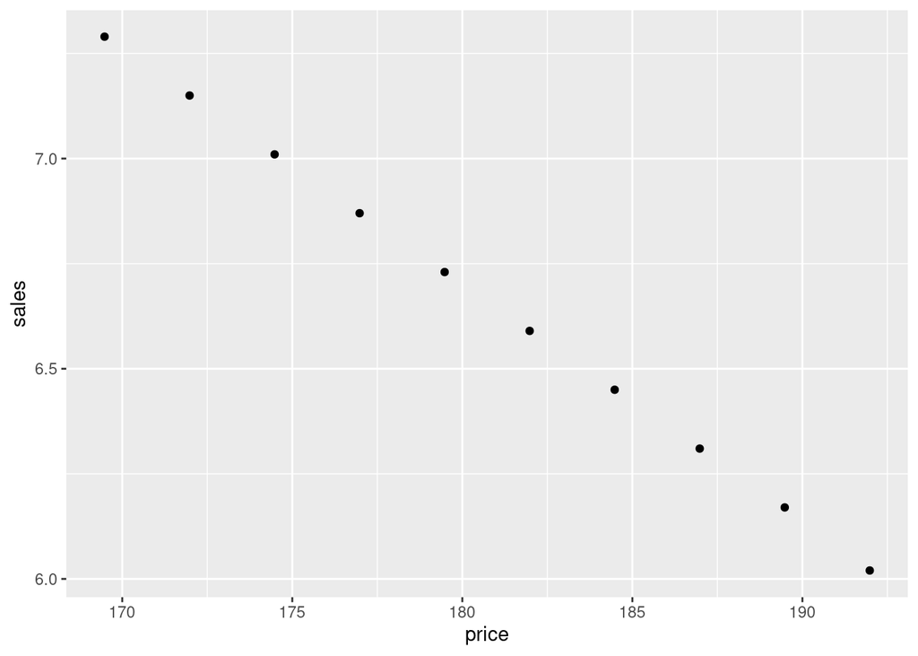

```r
good_results %>%
  ggplot(mapping = aes(x = price, y = sales)) +
  geom_point()
```

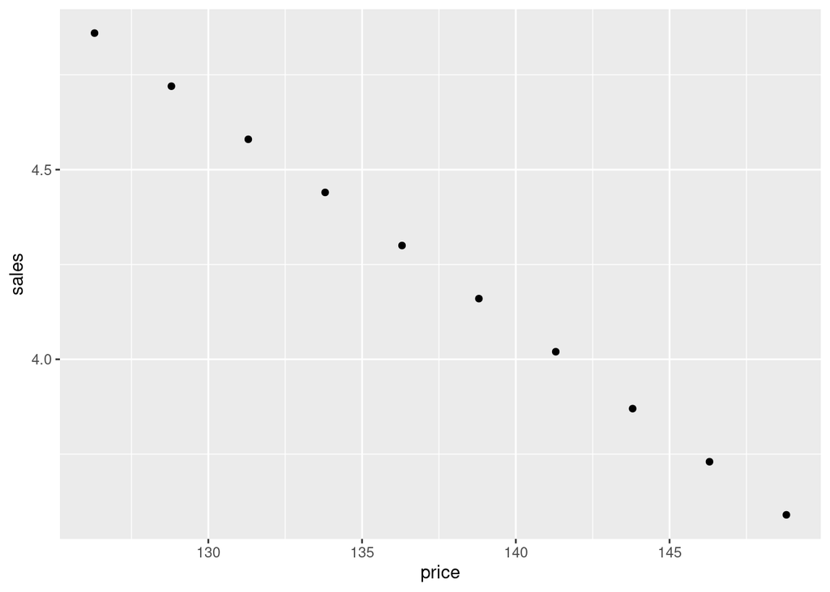

```r
bad_results %>%
  ggplot(mapping = aes(x = price, y = sales)) +
  geom_point()
```

**The optimal price range for costs between 40 to 85 for good shelf location is about $170 to $192 and bad shelf location of $126 to $149.**